# Crop Yields

AnnaClaire Marley

4/15/2020

```r
# load packages
library(tidyverse)
```

```r
# read in the data
clim <- read.table("clim.txt")
```

**1. Implement a model of almond yield anomaly (difference from average) in R based on this paper; You will be graded both on the “correctness” of the implementation and on “style”. Make sure you add some error checking. Use coefficients in the paper as default values, but make sure you can vary them.**

**2. Have the function return almond yield anomaly for each year, and max and minimum yields over a time series of multiple year inputs**

*Almond model from Lobell et al:*

Y = -0.015T<sub>n,2</sub> - 0.0046T<sup>2</sup><sub>n,2</sub> - 0.07P<sub>1</sub> + 0.0043P<sup>2</sup><sub>1</sub> + 0.28

- Y: yield anomaly (ton/acre)
- Tn: min temperature (degrees C)
- Tx: maximum temperature
- P: precipitation (mm)
- subscripted numbers represent month of climate variable.
- So almond yields need min temp from feb and precipitation from jan

Test function on the clim dataset

```r
source('calc_crop_yield.R')
calc_crop_yield(clim)
```

```
## $data
##    year   yield_anom
## 1  1988           NA
## 2  1989   -0.3552237
## 3  1990    9.2906757
## 4  1991   68.9130633
## 5  1992   15.4280698
## 6  1993   20.2083803
## 7  1994    2.4820009
## 8  1995 1919.9811511
## 9  1996    3.5818399
## 10 1997  329.6938750
## 11 1998   27.8636956
## 12 1999   -0.1436364
## 13 2000    9.5999883
```

[output cut: 16 more lines]

**3. With the climate data provided (clim.txt), *use your model* to estimate how almond yield anomalies for each year in the record - graph the results.**

```r
# get the dataframe
almond_yield <- calc_crop_yield(clim)$data
```

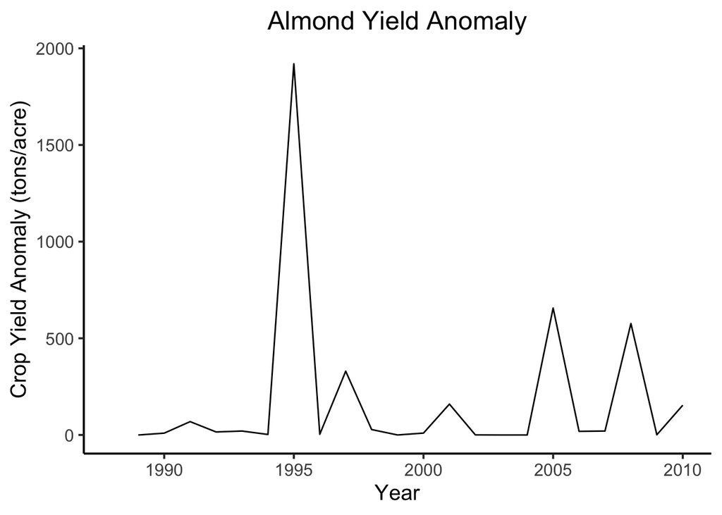

```r
# graph the result
ggplot(almond_yield, aes(x = year, y = yield_anom)) +
  geom_line() +
  labs(
    x = "Year",
    y = "Crop Yield Anomaly (tons/acre)",
    title = "Almond Yield Anomaly"
  ) +
  scale_y_continuous() +
  theme_classic(base_size = 15) +
  theme(plot.title = element_text(hjust = 0.5))
```

**4. Use model to estimate the mean annual yield anomaly if the last 20 years had been 2C warmer**

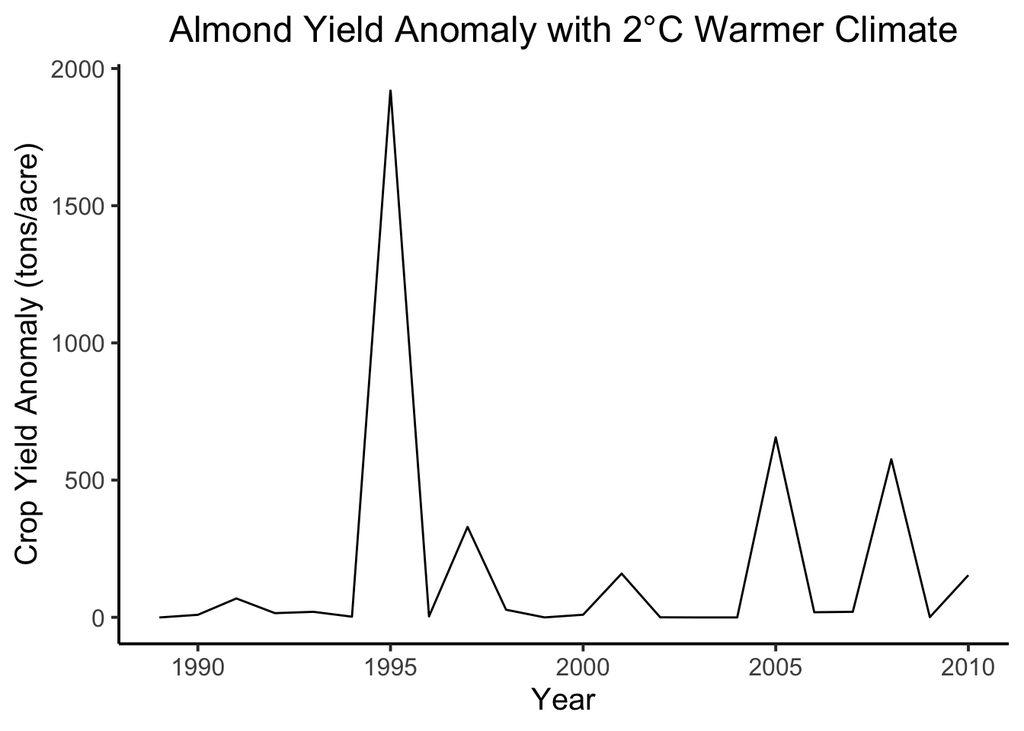

```r
# add two degrees to temperature
clim_2c <- clim %>%
  mutate(tmin_c = tmin_c + 2) %>%
  mutate(tmax_c = tmax_c + 2) %>%
  filter(year != 1988)

yield_2c <- calc_crop_yield(clim_2c)$data

# graph the yield anomaly when 2c warmer
ggplot(yield_2c, aes(x = year, y = yield_anom)) +
  geom_line() +
  labs(
    x = "Year",
    y = "Crop Yield Anomaly (tons/acre)",
    title = "Almond Yield Anomaly with 2°C Warmer Climate"
  ) +
  scale_y_continuous() +
  theme_classic(base_size = 15) +
  theme(plot.title = element_text(hjust = 0.5))
```

```r
# Mean annual yield anomaly
mean_annual = round(mean(yield_2c$yield_anom),2)
mean_annual
```

```
## [1] 181.22
```

**5. Vary one of the parameter by sampling from a normal distribution with mean the value from Lobell et al., (2006) and standard deviation 10% of the mean - create a box plot of mean annual yield anomaly for baseline and 2C climate (where boxes show variation due to uncertanty in the parameter)**

```r
# take out 1988 from the clim dataframe to not show the error messages
clim_clean <- clim %>%
  filter(year != 1988)

# setting the normal distribution on the b parameter
b_par = rnorm(100, mean = -0.0046, sd = 0.1)
b = as.data.frame(b_par) # make it a dataframe

# run the function 100 times with all the selection of b parameters
b$yield_anom_mean = NA
b$yield_anom_mean_2c = NA
for (i in 1:nrow(b)) {
  # regular temperatures
  out <- calc_crop_yield(clim_clean, b_param = b$b_par[i])$data
  mean <- mean(na.omit(out$yield_anom))
  b$yield_anom_mean[i] = mean

  # 2 degrees warmer temperatures
  out <- calc_crop_yield(clim_2c, b_param = b$b_par[i])$data
  mean <- mean(na.omit(out$yield_anom))
  b$yield_anom_mean_2c[i] = mean
}
```

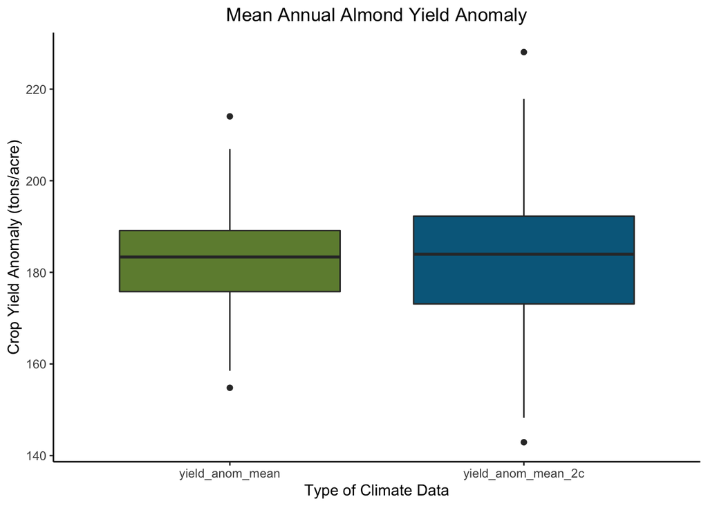

```r
# make a boxplot of results
boxplot_df <- b %>%
  gather(key = "clim_type", value ="yield_anomaly", -b_par)

ggplot(boxplot_df, aes(x = clim_type, y = yield_anomaly)) +
  geom_boxplot(aes(fill = clim_type), show.legend = FALSE) +
  scale_fill_manual(values = c("darkolivegreen4", "deepskyblue4")) +
  labs(
    x = "Type of Climate Data",
    y = "Crop Yield Anomaly (tons/acre)",
    title = "Mean Annual Almond Yield Anomaly"
  ) +
  theme_classic() +
  theme(plot.title = element_text(hjust = 0.5))
```